# Generative Models for Discrete Data.Rmd

```
https://web.stanford.edu/class/bios221/book/Chap-Generative.html
```

## Real Example - HIV

[output not shown]

```r
# odds of excactly 3 instances in a piosson distribution with rate 5
dpois(x = 3, lambda = 5)
```

```
## [1] 0.1403739
```

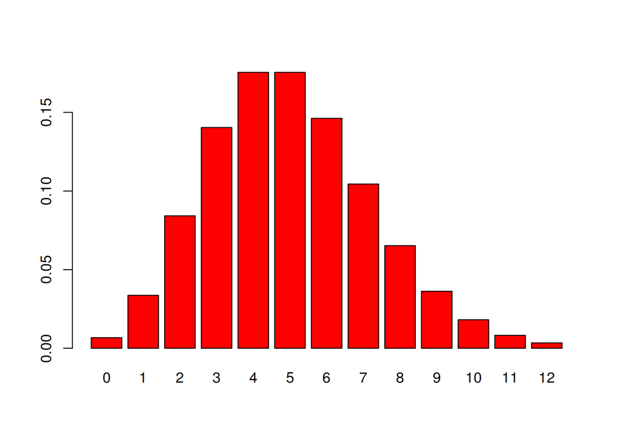

```r
# pass a range using :
barplot(dpois(0:12, 5), names.arg = 0:12, col = "red")
```

The Poisson distribution is a good model for rare events such as mutations.

## Using discrete probability models

[output not shown]

```r
# Blood types of 19 hypoethetical people
genotype = c("AA","AO","BB","AO","OO","AO","AA","BO","BO",
             "AO","BB","AO","BO","AB","OO","AB","BB","AO","AO")
table(genotype)
```

```
## genotype
## AA AB AO BB BO OO
##  2  2  7  3  3  2
```

```
Tossing a coin has two possible outcomes. This simple experiment, called a Bernoulli trial, is modeled using a so-called Bernoulli random variable. Understanding this building block will take you surprisingly far. We can use it to build more complex models.

Let’s try a few experiments to see what some of these random variables look like. We use special R functions tailored to generate outcomes for each type of distribution. They all start with the letter r, followed by a specification of the model, here rbinom, where binom is the abbreviation used for …

Suppose we want to simulate a sequence of 15 fair coin tosses. To get the outcome of 15 Bernoulli trials with a probability of success equal to 0.5 (a fair coin), we write
```

```r
# fair coin
rbinom(15, prob = 0.5, size = 1)
```

```
##  [1] 1 1 0 0 1 0 0 0 0 1 1 1 0 1 1
```

(Say a box has two sections, and the right is 2/3 of the box, the left, 1/3)

```r
# emulate the 2/3 falling into the right of the box
rbinom(15, prob = 2/3, size = 1)
```

```
##  [1] 1 1 0 0 1 1 1 0 1 0 1 1 1 1 1
```

```r
# to just get the number, not the vector of results:
rbinom(1, prob = 2/3, size = 12)
```

```
## [1] 9
```

```r
# probability mass distribution
probabilities = dbinom(0:15, prob = 0.3, size = 15)
round(probabilities, 2)
```

```
##  [1] 0.00 0.03 0.09 0.17 0.22 0.21 0.15 0.08 0.03 0.01 0.00 0.00 0.00 0.00
## [15] 0.00 0.00
```

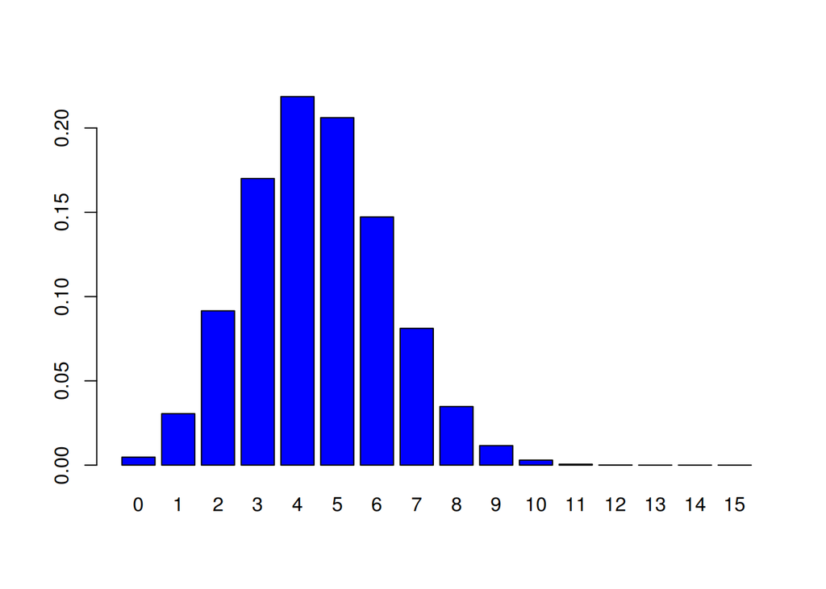

```r
# we can plot it thusly
barplot(probabilities, names.arg = 0:15, col = "blue")
```

## Poisson distributions

```
When the probability of success p is small and the number of trials n large, the binomial distribution B(n,p) can be faithfully approximated by a simpler distribution, the Poisson distribution with rate parameter lambda = np. We already used this fact, and this distribution, in the HIV example.
```

### Question 1.5

```
    What is the probability mass distribution of observing 0:12 mutations in a genome of n=104 nucleotides, when the probability is p=5×10−4 per nuceotide? Is it similar when modeled by the binomial B(n,p) distribution and by the Poisson(λ=np) distribution?
```

[output not shown]

```r
# example - rate of 5, P(X=3) - will be like the first example
5^3 * exp(-5) / factorial(3)
```

```
## [1] 0.1403739
```

```
Simulate a mutation process along 10,000 positions with a mutation rate of 5×10−4 and count the number of mutations. Repeat this many times and plot the distribution with the barplot function
```

```r
rbinom(1, prob = 5e-4, size = 10000)
```

```
## [1] 5
```

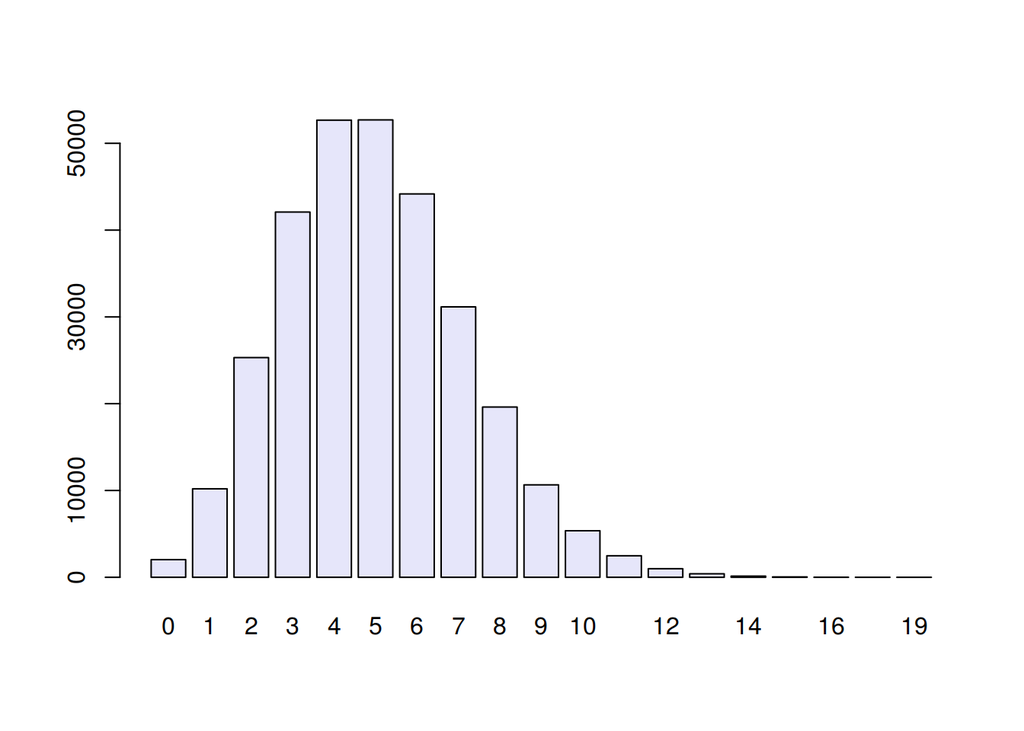

```r
simulations = rbinom(n = 300000, prob = 5e-4, size = 10000)
barplot(table(simulations), col = "lavender")
```

## Generateive Model for Epitope Prediction

Let’s say we’re a hypothetical elisa-based experiment.

```
The baseline noise level per position, or more precisely the false positive rate, is 1%. This is the probability of declaring a hit – we think we have an epitope – when there is none. We write this P( declare epitope | no epitope)

The protein is tested at 100 different positions, supposed to be independent.

We are going to examine a collection of 50 patient samples.
```

Each patients’ results are presented as a vector of length 100 with a 0 being not hit and a 1 being a hit (and a potential for an allergic reaction).

Our goal is:

```
 Verify by simulation that the sum of 50 independent Bernoulli variables with p = 0.01 is –to good enough approximation– the same as a Poisson(0.5) random variable.
```

We know that, due the false positive rate, there is a 1% chance a result is due to chance.

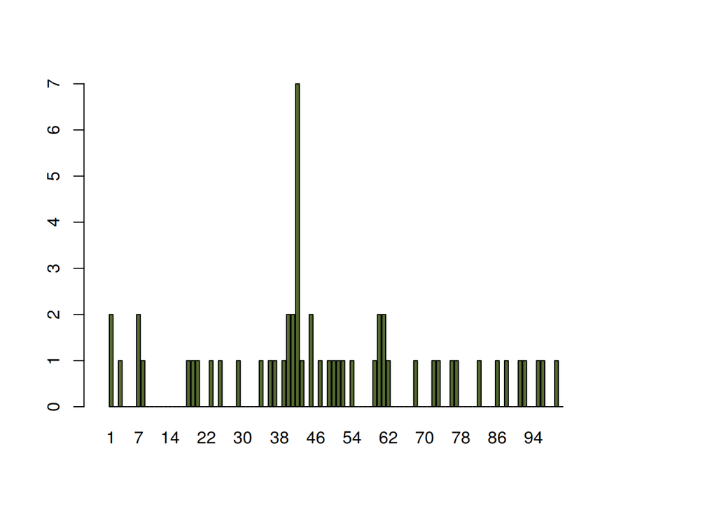

```r
# load it randomly into the namespace because we hate ourselves
load("data/e100.RData")

# plot the results of our simulated experiment
barplot(e100, ylim = c(0, 7), width = 0.7, xlim = c(-0.5, 100.5),
  names.arg = seq(along = e100), col = "darkolivegreen")
```

Obviously, we see the 7 right away. We’d like to ask ourselves what the odds are that we get such a result. It’s tempting to ask what are the odds, given Piosson(0.5), that we get a 7, though the more appropriate question is what are the odds, given 100 repititions, that 7 is the maximum.

The takeaway here is that we can calculate it in R explicity but are probably better off running a monte carlo simulation:

```r
set.seed(123)

# run 100,000 simulations of a random piosson distribution of 100 values with l = 0.5
maxes = replicate(100000, {
  # find the max each time
  max(rpois(100, 0.5))
})

# show a table of the max values
table(maxes)
```

```
## maxes
##     1     2     3     4     5     6     7     8
##     4 23640 60256 14426  1526   138     9     1
```

We see that the max was 7 or higher 10 times.

```r
# we can find the answer thusly
sum(maxes >=7)/length(maxes)
```

```
## [1] 1e-04
```

```r
# or we can use this shortcut getting 1s and 0s from the boolean vector
# find the mean of the boolean vector'
mean(maxes >= 7)
```

```
## [1] 1e-04
```

## Multinomial Dustributions

With DNA, there are four normal nucleotides, ATCG. The odds still add up to the total, ie, pA+pT+pG+pC = 1.

### Q 1.7

```
Suppose we have four boxes that are equally likely. Using the formula, what is the probability of observing 4 in the first box, 2 in the second box, and none in the two other boxes?
```

```r
# 4 values with odds of 1/4 each
pvec = rep(1/4, 4) #  0.25 0.25 0.25 0.25

t(rmultinom(1, prob = pvec, size = 8))
```

```
##      [,1] [,2] [,3] [,4]
## [1,]    2    0    3    3
```

### Question 1.9

How do you interpret the difference between rmultinom(n = 8, prob = pvec, size = 1) and rmultinom(n = 1, prob = pvec, size = 8)? Hint: remember what we did in Sections 1.3.1 and 1.3.2.

```r
# this has 1 trials of 1/4 8 times
rmultinom(n = 8, prob = pvec, size = 1)
```

```
##      [,1] [,2] [,3] [,4] [,5] [,6] [,7] [,8]
## [1,]    0    0    0    0    0    0    0    0
## [2,]    0    0    1    0    0    0    0    1
## [3,]    0    1    0    0    0    0    1    0
## [4,]    1    0    0    1    1    1    0    0
```

```r
# this has 8 trials of 1/4 once
rmultinom(n = 1, prob = pvec, size = 8)
```

```
##      [,1]
## [1,]    2
## [2,]    4
## [3,]    2
## [4,]    0
```

## 1.4.1 Simulating for Power

[output not shown]

```r
obsunder0 = rmultinom(1000, prob = pvec, size = 20)

dim(obsunder0)
```

```
## [1]    4 1000
```

```r
obsunder0[, 1:11]
```

```
##      [,1] [,2] [,3] [,4] [,5] [,6] [,7] [,8] [,9] [,10] [,11]
## [1,]    3    5    7    3    4    5    8    8    5     4     4
## [2,]    7    2    7    5    8    4    2    4    7     4     2
## [3,]    6    4    1    6    4    5    7    5    7     4     7
## [4,]    4    9    5    6    4    6    3    3    1     8     7
```

$$\begin{equation}
{\tt stat}=\frac{(E_A-x_A)^2}{E_A}+
\frac{(E_C-x_C)^2}{E_C}+
\frac{(E_G-x_G)^2}{E_G}+
\frac{(E_T-x_T)^2}{E_T}
=\sum_i\frac{(E_i-x_i)^2}{E_i}
\tag{1.1}
\end{equation}$$